# 07 - Advanced Statistical Tests Answers

# Introduction and Setup

For these exercises, we will look at the core concepts from this lesson. Here, we’ll use a simulated data set that’s saved as a .csv in the inputs folder for this class.

```r
library(tidyverse)
# install.packages("car") # install if necessary (once per machine)
library(car)
library(ggpirate)
```

Next, we’ll load the data set for this exercise.

```r
factorial_data <- read_csv("inputs/factorial_data.csv")
```

## Question 1

Aggregate the data by subject such that you have 1 score per subject for the mean of the column Y across both A and B columns. Call the Y column mean_Y. Assign this to the object **data_agg**.

```r
data_agg <- factorial_data %>%
  group_by(subj_id, A, B) %>%
  summarise(mean_Y = mean(Y))
```

## Question 2

Generate summary statistics for the data set and a pirate plot of the data set. We want means, SDs, and ns for the table of summary statistics.

```r
data_agg %>%
  group_by(A, B) %>%
  summarise(mean = mean(mean_Y),
            sd = sd(mean_Y),
            n = n()
            )
```

| A | B | mean | sd | n |
| --- | --- | --- | --- | --- |
| A1 | B1 | 248.4599 | 14.04346 | 60 |
| A1 | B2 | 252.4373 | 23.58675 | 60 |
| A2 | B1 | 247.1118 | 13.85094 | 60 |
| A2 | B2 | 257.9548 | 24.33985 | 60 |

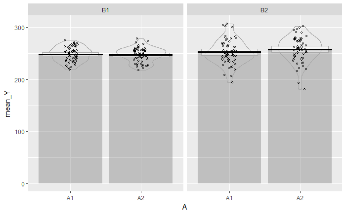

```r
data_agg %>%
  ggplot(mapping = aes(x = A, y = mean_Y)) +
  facet_wrap(~ B) +
  geom_pirate()
```

## Question 3

Define your contrasts such that you have main effects and interactions from any model fits. You may need to check your data types for this to work properly. *Hint*: use `mutate()` after the `ungroup()` function

```r
data_agg <- data_agg %>%
  ungroup() %>%
  as.tibble() %>%
  mutate(A = factor(A),
         B = factor(B)
         )
contrasts(data_agg$A) <- contr.sum
contrasts(data_agg$B) <- contr.sum
```

## Question 4

Fit the data set checking for all main effects and interactions.

```r
aov_fit <- aov(mean_Y ~ A * B, data = data_agg)
summary(aov_fit)
```

```
             Df Sum Sq Mean Sq F value  Pr(>F)
A             1    261     261   0.678 0.41103
B             1   3295    3295   8.570 0.00375 **
A:B           1    707     707   1.839 0.17636
Residuals   236  90732     384
---
Signif. codes:  0 *** 0.001 ** 0.01 * 0.05 . 0.1   1
```

## Question 5

```r
Anova(aov_fit, type = "III")
```

```
Anova Table (Type III tests)

Response: mean_Y
              Sum Sq  Df    F value    Pr(>F)
(Intercept) 15179446   1 39482.7470 < 2.2e-16 ***
A                261   1     0.6782  0.411030
B               3295   1     8.5697  0.003752 **
A:B              707   1     1.8390  0.176361
Residuals      90732 236
---
Signif. codes:  0 *** 0.001 ** 0.01 * 0.05 . 0.1   1
```

**Answer**: The sum of squares were unaffected as we had a balanced data set.

## Question 6

Explore the parameter estimates from your ANOVA model, and briefly report your findings in text (1 sentence max).

```r
summary.lm(aov_fit)
```

```
Call:
aov(formula = mean_Y ~ A * B, data = data_agg)

Residuals:
    Min      1Q  Median      3Q     Max
-76.630 -11.640   0.825  12.463  54.767

Coefficients:
            Estimate Std. Error t value Pr(>|t|)
(Intercept)  251.491      1.266 198.703  < 2e-16 ***
A1            -1.042      1.266  -0.824  0.41103
B1            -3.705      1.266  -2.927  0.00375 **
A1:B1          1.716      1.266   1.356  0.17636
---
Signif. codes:  0 *** 0.001 ** 0.01 * 0.05 . 0.1   1

Residual standard error: 19.61 on 236 degrees of freedom
Multiple R-squared:  0.04487,   Adjusted R-squared:  0.03273
F-statistic: 3.696 on 3 and 236 DF,  p-value: 0.01252
```

**Answer**: We found a significant main effect of B on (*t* = 2.93, *p* = .004), however the main effect of A, and the interaction between A and B was non-significant (both *p*s > .05).